# Coffee Ratings

Joseph Pope

2020-07-07

A TidyTuesday project modelling coffee ratings predictions

# Intro

Today I am going to explore Coffee Ratings for this week’s Tidy Tuesday challenge. The data comes from the [Coffee Quality Database](https://github.com/jldbc/coffee-quality-database). The great thing about Tidy Tuesday is that we can do whatever we want with the data. There are no rules or directions!

This data is very interesting and looks ripe for a predictive model. I can use the ratings provided to predict either a quantitative method, like what the ‘total_cup_score’ (Overall rating) is, or a qualitative measure, like what species of bean (Arabica or Robusta) or the country of origin.

Predicting scores strikes me as a classic regression problem, best tackled by linear models or random forests, and classification could be solved with logistic regression, Naive Bayes, SVM or even neural networks. I’ve NEVER used `tidymodels` before, so let’s give it a go and see what we can learn.

But first, some brief background of our data from the TidyTuesday repo:

> There is data for both Arabica and Robusta beans, across many countries and professionally rated on a 0-100 scale. All sorts of scoring/ratings for things like acidity, sweetness, fragrance, balance, etc - may be useful for either separating into visualizations/categories or for modeling/recommenders.

> Wikipedia on Coffee Beans:

> The two most economically important varieties of coffee plant are the Arabica and the Robusta; ~60% of the coffee produced worldwide is Arabica and ~40% is Robusta. Arabica beans consist of 0.8–1.4% caffeine and Robusta beans consist of 1.7–4% caffeine.

Setup

```r
library(tidytuesdayR)
library(tidyverse)
library(tidymodels)
library(knitr)
library(kableExtra)
```

```r
knitr::opts_chunk$set(
    fig.height = 5,
    fig.width = 8,
    message = FALSE,
    warning = FALSE,
    dpi = 180,
    include = TRUE
)
```

Load the data

```r
tuesdata <- tidytuesdayR::tt_load(2020, week = 28)
coffee_ratings <- tuesdata$coffee_ratings
```

# EDA

Now that we have our data and let’s dive in. Let’s review the summary statistics with skimr.

```r
coffee_ratings %>%
  skimr::skim()
```

Data summary

| Name | Piped data |
| --- | --- |
| Number of rows | 1339 |
| Number of columns | 43 |
| _______________________ |  |
| Column type frequency: |  |
| character | 24 |
| numeric | 19 |
| ________________________ |  |
| Group variables | None |

**Variable type: character**

| skim_variable | n_missing | complete_rate | min | max | empty | n_unique | whitespace |
| --- | --- | --- | --- | --- | --- | --- | --- |
| species | 0 | 1.00 | 7 | 7 | 0 | 2 | 0 |
| owner | 7 | 0.99 | 3 | 50 | 0 | 315 | 0 |
| country_of_origin | 1 | 1.00 | 4 | 28 | 0 | 36 | 0 |
| farm_name | 359 | 0.73 | 1 | 73 | 0 | 571 | 0 |
| lot_number | 1063 | 0.21 | 1 | 71 | 0 | 227 | 0 |
| mill | 315 | 0.76 | 1 | 77 | 0 | 460 | 0 |
| ico_number | 151 | 0.89 | 1 | 40 | 0 | 847 | 0 |
| company | 209 | 0.84 | 3 | 73 | 0 | 281 | 0 |
| altitude | 226 | 0.83 | 1 | 41 | 0 | 396 | 0 |
| region | 59 | 0.96 | 2 | 76 | 0 | 356 | 0 |
| producer | 231 | 0.83 | 1 | 100 | 0 | 691 | 0 |
| bag_weight | 0 | 1.00 | 1 | 8 | 0 | 56 | 0 |
| in_country_partner | 0 | 1.00 | 7 | 85 | 0 | 27 | 0 |
| harvest_year | 47 | 0.96 | 3 | 24 | 0 | 46 | 0 |
| grading_date | 0 | 1.00 | 13 | 20 | 0 | 567 | 0 |
| owner_1 | 7 | 0.99 | 3 | 50 | 0 | 319 | 0 |
| variety | 226 | 0.83 | 4 | 21 | 0 | 29 | 0 |
| processing_method | 170 | 0.87 | 5 | 25 | 0 | 5 | 0 |
| color | 218 | 0.84 | 4 | 12 | 0 | 4 | 0 |
| expiration | 0 | 1.00 | 13 | 20 | 0 | 566 | 0 |
| certification_body | 0 | 1.00 | 7 | 85 | 0 | 26 | 0 |
| certification_address | 0 | 1.00 | 40 | 40 | 0 | 32 | 0 |
| certification_contact | 0 | 1.00 | 40 | 40 | 0 | 29 | 0 |
| unit_of_measurement | 0 | 1.00 | 1 | 2 | 0 | 2 | 0 |

**Variable type: numeric**

| skim_variable | n_missing | complete_rate | mean | sd | p0 | p25 | p50 | p75 | p100 | hist |
| --- | --- | --- | --- | --- | --- | --- | --- | --- | --- | --- |
| total_cup_points | 0 | 1.00 | 82.09 | 3.50 | 0 | 81.08 | 82.50 | 83.67 | 90.58 | ▁▁▁▁▇ |
| number_of_bags | 0 | 1.00 | 154.18 | 129.99 | 0 | 14.00 | 175.00 | 275.00 | 1062.00 | ▇▇▁▁▁ |
| aroma | 0 | 1.00 | 7.57 | 0.38 | 0 | 7.42 | 7.58 | 7.75 | 8.75 | ▁▁▁▁▇ |
| flavor | 0 | 1.00 | 7.52 | 0.40 | 0 | 7.33 | 7.58 | 7.75 | 8.83 | ▁▁▁▁▇ |
| aftertaste | 0 | 1.00 | 7.40 | 0.40 | 0 | 7.25 | 7.42 | 7.58 | 8.67 | ▁▁▁▁▇ |
| acidity | 0 | 1.00 | 7.54 | 0.38 | 0 | 7.33 | 7.58 | 7.75 | 8.75 | ▁▁▁▁▇ |
| body | 0 | 1.00 | 7.52 | 0.37 | 0 | 7.33 | 7.50 | 7.67 | 8.58 | ▁▁▁▁▇ |
| balance | 0 | 1.00 | 7.52 | 0.41 | 0 | 7.33 | 7.50 | 7.75 | 8.75 | ▁▁▁▁▇ |
| uniformity | 0 | 1.00 | 9.83 | 0.55 | 0 | 10.00 | 10.00 | 10.00 | 10.00 | ▁▁▁▁▇ |
| clean_cup | 0 | 1.00 | 9.84 | 0.76 | 0 | 10.00 | 10.00 | 10.00 | 10.00 | ▁▁▁▁▇ |
| sweetness | 0 | 1.00 | 9.86 | 0.62 | 0 | 10.00 | 10.00 | 10.00 | 10.00 | ▁▁▁▁▇ |
| cupper_points | 0 | 1.00 | 7.50 | 0.47 | 0 | 7.25 | 7.50 | 7.75 | 10.00 | ▁▁▁▇▁ |
| moisture | 0 | 1.00 | 0.09 | 0.05 | 0 | 0.09 | 0.11 | 0.12 | 0.28 | ▃▇▅▁▁ |
| category_one_defects | 0 | 1.00 | 0.48 | 2.55 | 0 | 0.00 | 0.00 | 0.00 | 63.00 | ▇▁▁▁▁ |
| quakers | 1 | 1.00 | 0.17 | 0.83 | 0 | 0.00 | 0.00 | 0.00 | 11.00 | ▇▁▁▁▁ |
| category_two_defects | 0 | 1.00 | 3.56 | 5.31 | 0 | 0.00 | 2.00 | 4.00 | 55.00 | ▇▁▁▁▁ |
| altitude_low_meters | 230 | 0.83 | 1750.71 | 8669.44 | 1 | 1100.00 | 1310.64 | 1600.00 | 190164.00 | ▇▁▁▁▁ |
| altitude_high_meters | 230 | 0.83 | 1799.35 | 8668.81 | 1 | 1100.00 | 1350.00 | 1650.00 | 190164.00 | ▇▁▁▁▁ |
| altitude_mean_meters | 230 | 0.83 | 1775.03 | 8668.63 | 1 | 1100.00 | 1310.64 | 1600.00 | 190164.00 | ▇▁▁▁▁ |

# Check Initial Assumptions

I originally wanted to predict “total_cup_points”. However, after some review it appears that this field is simply the sum of ten other ratings, from aroma to cupper_points. What I really want to predict is Cupper Points. This is the reviewer’s (aka the Cupper’s) final overall rating for the cup of joe. I can use this as dependant variable in a regression analysis. This should help me identify which features (aroma, acidity, elevation, country of origin?) influence the final rating the most.

# Potential Features

Before we dig further into the data, let’s speculate what might factors go into a superior coffee bean. If coffee is like wine, then perhaps region (lat, long, altitude, preciptation, average hours of sunlight, etc) makes a big difference. Perhaps certain companies utilize best practices and farming techniques. Maybe certain processing methods are better than others. We are given the testing date and the expiration date, so we can add a feature that measures how fresh the beans are. These features and more could be really importnat or totally useless. I have no idea! Let’s see what the data has to say about it.

The wiki in the readme suggests that coffee beans are split 60/40 worldwide, by Arabica and Robusta. However, for this analysis the split is much more imbalanced. I thought it would be very interesting to build an Arabica vs. Robusta classifier but with such an imbalanced set I don’t think upsampling or other methods will be enough to build a robust model.

OR WILL IT????

```r
table(coffee_ratings$species)
```

```
##
## Arabica Robusta
##    1311      28
```

Let’s take a peak at the distribution of country of origin field. It is mentioned in the articles that Ethiopia wins top prize, however most of the coffees are from Central and South America.

```r
coffee_ratings %>%
  group_by(country_of_origin) %>%
  tally() %>%
  top_n(., 10) %>%
  arrange(desc(n))
```

```
## # A tibble: 10 x 2
##    country_of_origin                n
##    <chr>                        <int>
##  1 Mexico                         236
##  2 Colombia                       183
##  3 Guatemala                      181
##  4 Brazil                         132
##  5 Taiwan                          75
##  6 United States (Hawaii)          73
##  7 Honduras                        53
##  8 Costa Rica                      51
##  9 Ethiopia                        44
## 10 Tanzania, United Republic Of    40
```

Let’s pull this list of top 10 countries into a list to reference later.

```r
top_countries <- coffee_ratings %>%
  group_by(country_of_origin) %>%
  tally() %>%
  top_n(., 10) %>%
  arrange(desc(n)) %>%
  pull(country_of_origin)
```

Out of curiousity, let’s see the count of coffee bean color. This was news to me, but apparently coffee beans are mostly blue or green in color when fresh. It is only after roasting that the color darkens to that familiar, uh, “coffee-brown” color. If you learn nothing else today, you can at least learn this.

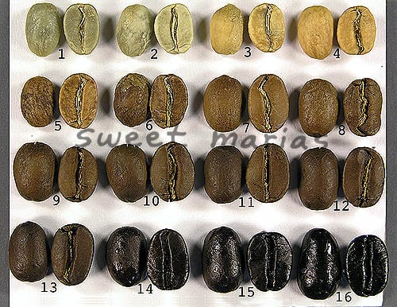

The Coffee Bean Spectrum

```r
table(coffee_ratings$color)
```

```
##
##   Blue-Green Bluish-Green        Green         None
##           85          114          870           52
```

Robusta is seen below with a higher modal peak, suggesting the species, known for its higher caffeine levels, is rated higher than Arabica. This could be due to a small sample size though.

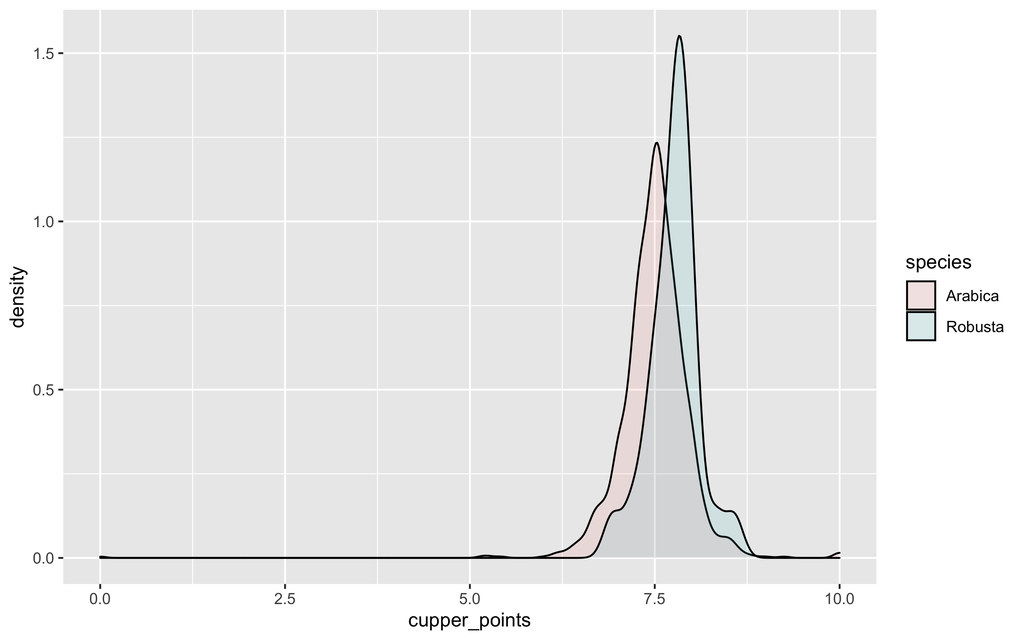

```r
coffee_ratings %>%
  mutate(id = row_number()) %>%
  select(id, species, cupper_points) %>%
  ggplot(aes(cupper_points, fill = species)) +
  geom_density(alpha = 0.1)
```

```r
  # geom_histogram(position = "identity", alpha = 0.7, show.legend = FALSE)
```

# TIDYMODELS

First thing to do is narrow our data and make it ripe for modeling. TidyTuesday mentions that Yorgos Askalidis already determined that altitude, processing_method and color have no bearing to the cupping score, and I think that makes sense. I will omit those features for now. That leaves us with species, country of origin and several ratings and measurements of the coffee samples. I am going to take the top ten countries only (out of 36 in the data) and lump the rest into “Other” with forcats.

```r
coffee <- coffee_ratings %>%
  mutate(id = row_number()) %>% # add ID field, convert NA to Other
  select(id, species, country_of_origin, variety, aroma:moisture) %>% # select features
  mutate(country_of_origin = case_when(
    country_of_origin %in% top_countries ~ country_of_origin,
    TRUE ~ "Other"
  )) %>%
  mutate_if(is.character, as.factor) %>% # convert country and variety to factors
  filter(cupper_points != 0) %>% # remove 0 point scores as junk data
  drop_na() # drop NA for country and variety fields. only affects 200 records
```

Split the data

I am stratifying by species, even though there aren’t many Robusta coffee samples in the data. This at least places the same ratio in train and test data sets.

```r
set.seed(1234)

coffee_split <- coffee %>%
  initial_split(strata = species)

coffee_train <- training(coffee_split)
coffee_test <- testing(coffee_split)
```

Naive model with no scaling or pre-processing

```r
lm_spec <- linear_reg() %>%
  set_engine(engine = "lm")

lm_spec
```

```
## Linear Regression Model Specification (regression)
##
## Computational engine: lm
```

```r
## Linear Regression Model Specification (regression)
##
## Computational engine: lm
lm_fit <- lm_spec %>%
  fit(cupper_points ~ .,
    data = coffee_train
  )

lm_fit
```

```
## parsnip model object
##
## Fit time:  457ms
##
## Call:
## stats::lm(formula = formula, data = data)
##
## Coefficients:
##                                   (Intercept)
##                                     2.1436057
##                                            id
##                                    -0.0003008
##                                speciesRobusta
##                                     0.1614311
##                     country_of_originColombia
##                                    -0.0963247
##                   country_of_originCosta Rica
##                                    -0.0187614
##                     country_of_originEthiopia
##                                     0.0520746
##                    country_of_originGuatemala
##                                    -0.0427146
##                     country_of_originHonduras
##                                    -0.0129326
##                       country_of_originMexico
##                                     0.0382506
##                        country_of_originOther
##                                     0.0231970
##                       country_of_originTaiwan
##                                    -0.1259858
## country_of_originTanzania, United Republic Of
##                                     0.0656485
##       country_of_originUnited States (Hawaii)
##                                    -0.3891800
##                          varietyBlue Mountain
##                                    -0.2279534
##                                varietyBourbon
##                                     0.0092837
##                                varietyCatimor
##                                     0.0215716
```

[output cut: 53 more lines]

```
##                                     0.2855495
##                                       acidity
##                                     0.0264013
##                                          body
##                                     0.0242591
##                                       balance
##                                     0.1904163
##                                    uniformity
##                                    -0.0026808
##                                     clean_cup
##                                     0.0059847
##                                     sweetness
##                                    -0.0284998
##                                      moisture
##                                    -0.4988843
```

```r
library(ranger)

rf_spec <- rand_forest(mode = "regression") %>%
  set_engine("ranger")

rf_spec
```

```
## Random Forest Model Specification (regression)
##
## Computational engine: ranger
```

```r
## Random Forest Model Specification (regression)
##
## Computational engine: ranger
rf_fit <- rf_spec %>%
  fit(cupper_points ~ .,
    data = coffee_train
  )

rf_fit
```

```
## parsnip model object
##
## Fit time:  559ms
## Ranger result
##
## Call:
##  ranger::ranger(formula = formula, data = data, num.threads = 1,      verbose = FALSE, seed = sample.int(10^5, 1))
##
## Type:                             Regression
## Number of trees:                  500
## Sample size:                      834
## Number of independent variables:  14
## Mtry:                             3
## Target node size:                 5
## Variable importance mode:         none
## Splitrule:                        variance
## OOB prediction error (MSE):       0.0414067
## R squared (OOB):                  0.7414545
```

Both models produce a hefty R squared, > .7! This makes me nervous as it’s likely too good to be true. I know that I skipped some preprocessing steps just to see how these models worked, so let’s go back and see if some `recipes` can bring my model back down to earth.

# Preprocessing With Recipes

1. Let’s create a bland, vanilla recipe to start off

```r
rec_obj <- recipe(cupper_points ~ ., data = coffee_train) %>%
  update_role(id, new_role = "ID") %>%
  step_normalize(all_predictors(), -all_nominal())

summary(rec_obj)
```

```
## # A tibble: 15 x 4
##    variable          type    role      source
##    <chr>             <chr>   <chr>     <chr>
##  1 id                numeric ID        original
##  2 species           nominal predictor original
##  3 country_of_origin nominal predictor original
##  4 variety           nominal predictor original
##  5 aroma             numeric predictor original
##  6 flavor            numeric predictor original
##  7 aftertaste        numeric predictor original
##  8 acidity           numeric predictor original
##  9 body              numeric predictor original
## 10 balance           numeric predictor original
## 11 uniformity        numeric predictor original
## 12 clean_cup         numeric predictor original
## 13 sweetness         numeric predictor original
## 14 moisture          numeric predictor original
## 15 cupper_points     numeric outcome   original
```

I tell the recipe not to use the “id” column in the analysis. I run summary on the recipe object and can see the type of role the variables have, as well as the type. I saw ‘nominal’ for the factor variables (species, country, variety) and got spooked a little, as I thought nominal == numeric. Of course, it does not. Nominal is yet another term to describe a factor/string/non-numeric.